# Race Analysis

## Setup

```r
library(tidyverse)
library(sf) # fix annoying tidyverse tibble issue with sfc_MULTIPOLYGON
library(clipr)
```

## Import data

import tables from our cleaned data. We’ll need both our county-only table and all-terminations

### County Data (with geometry)

```r
county_terminations_2020 <- read_rds("data-processed/01-county-terminations-2020.rds")

county_terminations_2020 %>% arrange(total_terminations %>% desc())
```

| geoid | name | variable | total_pop | geometry | year | asian | hispanic | white | black | native_american | other | race_not_stated | total_terminations | under_15_years | x15_to_19_years | x20_to_24_years | x25_to_29_years | x30_to_34_years | x35_to_39_years | x40_years | age_not_stated | terminations_per_pop |
| --- | --- | --- | --- | --- | --- | --- | --- | --- | --- | --- | --- | --- | --- | --- | --- | --- | --- | --- | --- | --- | --- | --- |
| 48201 | HARRIS | P1_001N | 4731145 |  | 2020 | 613 | 5546 | 2463 | 5403 | 10 | 23 | 28 | 14086 | 33 | 1089 | 3994 | 4189 | 2792 | 1481 | 508 | 0 | 3 |
| 48113 | DALLAS | P1_001N | 2613539 |  | 2020 | 507 | 2380 | 1113 | 3155 | 30 | 124 | 16 | 7325 | 10 | 536 | 2082 | 2305 | 1440 | 741 | 211 | 0 | 3 |
| 48029 | BEXAR | P1_001N | 2009324 |  | 2020 | 157 | 3116 | 1154 | 726 | 9 | 7 | 9 | 5178 | 6 | 447 | 1593 | 1464 | 979 | 513 | 176 | 0 | 3 |
| 48439 | TARRANT | P1_001N | 2110640 |  | 2020 | 266 | 1304 | 1293 | 1989 | 17 | 54 | 20 | 4943 | 8 | 424 | 1491 | 1382 | 941 | 556 | 141 | 0 | 2 |
| 48453 | TRAVIS | P1_001N | 1290188 |  | 2020 | 220 | 1093 | 1176 | 470 | 12 | 54 | 303 | 3328 | 4 | 231 | 912 | 953 | 703 | 384 | 141 | 0 | 3 |
| 48085 | COLLIN | P1_001N | 1064465 |  | 2020 | 341 | 262 | 524 | 441 | 8 | 45 | 4 | 1625 | 4 | 94 | 392 | 436 | 334 | 258 | 107 | 0 | 2 |
| 48157 | FORT BEND | P1_001N | 822779 |  | 2020 | 171 | 347 | 306 | 605 | 3 | 8 | 3 | 1443 | 3 | 100 | 360 | 339 | 324 | 226 | 91 | 0 | 2 |
| 48121 | DENTON | P1_001N | 906422 |  | 2020 | 133 | 263 | 472 | 414 | 13 | 35 | 5 | 1335 | 2 | 93 | 416 | 347 | 255 | 160 | 62 | 0 | 1 |
| 48215 | HIDALGO | P1_001N | 870781 |  | 2020 | 12 | 870 | 187 | 10 | 1 | 0 | 1 | 1081 | 1 | 122 | 354 | 279 | 199 | 94 | 32 | 0 | 1 |
| 48027 | BELL | P1_001N | 370647 |  | 2020 | 53 | 193 | 249 | 395 | 5 | 28 | 82 | 1005 | 2 | 97 | 314 | 313 | 171 | 88 | 20 | 0 | 3 |

[output cut: 244 more lines]

### All terminations

Including out of state and unknown counties

```r
all_terminations <- read_rds("data-processed/02-all-terminations.rds") ## table including out of state and country rows

all_terminations %>% arrange(year)
```

| year | county | asian | hispanic | white | black | native_american | other | race_not_stated | total_terminations | under_15_years | x15_to_19_years | x20_to_24_years | x25_to_29_years | x30_to_34_years | x35_to_39_years | x40_years | age_not_stated |
| --- | --- | --- | --- | --- | --- | --- | --- | --- | --- | --- | --- | --- | --- | --- | --- | --- | --- |
| 2010 | ANDERSON | 0 | 5 | 35 | 11 | 1 | 2 | 0 | 54 | 1 | 5 | 20 | 12 | 8 | 6 | 2 | 0 |
| 2010 | ANDREWS | 0 | 6 | 4 | 1 | 0 | 0 | 0 | 11 | 0 | 1 | 4 | 0 | 4 | 2 | 0 | 0 |
| 2010 | ANGELINA | 1 | 28 | 79 | 43 | 1 | 1 | 1 | 154 | 0 | 17 | 61 | 39 | 23 | 9 | 5 | 0 |
| 2010 | ARANSAS | 1 | 23 | 29 | 1 | 0 | 0 | 0 | 54 | 1 | 5 | 22 | 13 | 6 | 5 | 2 | 0 |
| 2010 | ARCHER | 0 | 0 | 5 | 1 | 0 | 0 | 0 | 6 | 0 | 1 | 2 | 2 | 1 | 0 | 0 | 0 |
| 2010 | ARMSTRONG | 0 | 0 | 1 | 0 | 0 | 0 | 0 | 1 | 0 | 1 | 0 | 0 | 0 | 0 | 0 | 0 |
| 2010 | ATASCOSA | 0 | 45 | 23 | 2 | 0 | 1 | 2 | 73 | 2 | 15 | 26 | 10 | 9 | 9 | 2 | 0 |
| 2010 | AUSTIN | 1 | 15 | 31 | 12 | 0 | 0 | 1 | 60 | 0 | 7 | 27 | 12 | 8 | 4 | 2 | 0 |
| 2010 | BAILEY | 0 | 2 | 2 | 0 | 0 | 0 | 0 | 4 | 0 | 0 | 3 | 1 | 0 | 0 | 0 | 0 |
| 2010 | BANDERA | 1 | 7 | 19 | 0 | 0 | 0 | 0 | 27 | 0 | 4 | 6 | 10 | 3 | 3 | 1 | 0 |

[output cut: 2828 more lines]

### Totals reported

```r
total_terminations <- read_rds("data-processed/03-itop-totals.rds")

total_terminations
```

| sheet | county | asian | hispanic | white | black | native_american | other | race_not_stated | total | under_15_years | x15_to_19_years | x20_to_24_years | x25_to_29_years | x30_to_34_years | x35_to_39_years | x40_years | age_not_stated |
| --- | --- | --- | --- | --- | --- | --- | --- | --- | --- | --- | --- | --- | --- | --- | --- | --- | --- |
| 2020 | TX RESIDENT TOTAL | 2830 | 20175 | 14458 | 16397 | 145 | 501 | 669 | 55175 | 107 | 4632 | 16315 | 15779 | 10496 | 5885 | 1960 | 1 |
| 2020 | TOTAL REPORTED | 2866 | 20348 | 14864 | 16942 | 150 | 511 | 677 | 56358 | 109 | 4713 | 16670 | 16147 | 10717 | 6006 | 1995 | 1 |
| 2019 | TX RESIDENT TOTAL | 3272 | 21905 | 14874 | 15780 | 127 | 571 | 91 | 56620 | 108 | 5003 | 16479 | 16095 | 10779 | 6087 | 2068 | 1 |
| 2019 | TOTAL REPORTED | 3310 | 22296 | 15288 | 16231 | 135 | 576 | 93 | 57929 | 111 | 5110 | 16885 | 16492 | 11012 | 6208 | 2110 | 1 |
| 2018 | TX RESIDENT TOTAL | 3185 | 20989 | 14780 | 14588 | 171 | 558 | 72 | 54343 | 109 | 4799 | 15956 | 15565 | 10177 | 5832 | 1905 | 0 |
| 2018 | TOTAL REPORTED | 3226 | 21449 | 15182 | 14918 | 183 | 566 | 72 | 55596 | 113 | 4899 | 16338 | 15910 | 10409 | 5976 | 1951 | 0 |
| 2017 | TX RESIDENT TOTAL | 3223 | 20325 | 14196 | 14087 | 168 | 616 | 54 | 52669 | 113 | 4777 | 15631 | 14964 | 9751 | 5556 | 1874 | 3 |
| 2017 | TOTAL REPORTED | 3276 | 20754 | 14561 | 14389 | 187 | 622 | 54 | 53843 | 115 | 4879 | 16008 | 15310 | 9942 | 5671 | 1915 | 3 |
| 2016 | TX RESIDENT TOTAL | 3097 | 20252 | 14984 | 14011 | 169 | 643 | 201 | 53357 | 108 | 4947 | 16126 | 15011 | 9693 | 5583 | 1866 | 23 |
| 2016 | TOTAL REPORTED | 3151 | 20668 | 15340 | 14312 | 183 | 649 | 204 | 54507 | 110 | 5040 | 16485 | 15340 | 9907 | 5695 | 1907 | 23 |

[output cut: 12 more lines]

## Goals

- Assess counties with highest termination rates on (may need to do this on average) √
- What groups have the highest termination rates? √
- How do those compare with those group’s share of the population? √
- Were there any noticeable trends in Texas abortion rates before the restriction was passed this year? (e.g. were they dropping, staying the same, increasing etc) √
- What races were most likely to leave the state for procedures? Who were the least likely? √
- What percentage of abortions occurred outside the state vs inside in 2020? What about 2019 (because COVID may have mattered here) √

## Highest rates in 2020

What counties had the highest rates in 2020?

```r
terminations_rates_2020 <- county_terminations_2020 %>%
  arrange(
    terminations_per_pop %>% desc()
  )

terminations_rates_2020
```

| geoid | name | variable | total_pop | geometry | year | asian | hispanic | white | black | native_american | other | race_not_stated | total_terminations | under_15_years | x15_to_19_years | x20_to_24_years | x25_to_29_years | x30_to_34_years | x35_to_39_years | x40_years | age_not_stated | terminations_per_pop |
| --- | --- | --- | --- | --- | --- | --- | --- | --- | --- | --- | --- | --- | --- | --- | --- | --- | --- | --- | --- | --- | --- | --- |
| 48301 | LOVING | P1_001N | 64 |  | 2020 | 0 | 0 | 2 | 0 | 0 | 0 | 0 | 2 | 0 | 0 | 0 | 1 | 1 | 0 | 0 | 0 | 31 |
| 48269 | KING | P1_001N | 265 |  | 2020 | 0 | 0 | 0 | 1 | 0 | 0 | 0 | 1 | 0 | 0 | 1 | 0 | 0 | 0 | 0 | 0 | 4 |
| 48443 | TERRELL | P1_001N | 760 |  | 2020 | 0 | 3 | 0 | 0 | 0 | 0 | 0 | 3 | 0 | 1 | 0 | 2 | 0 | 0 | 0 | 0 | 4 |
| 48027 | BELL | P1_001N | 370647 |  | 2020 | 53 | 193 | 249 | 395 | 5 | 28 | 82 | 1005 | 2 | 97 | 314 | 313 | 171 | 88 | 20 | 0 | 3 |
| 48029 | BEXAR | P1_001N | 2009324 |  | 2020 | 157 | 3116 | 1154 | 726 | 9 | 7 | 9 | 5178 | 6 | 447 | 1593 | 1464 | 979 | 513 | 176 | 0 | 3 |
| 48113 | DALLAS | P1_001N | 2613539 |  | 2020 | 507 | 2380 | 1113 | 3155 | 30 | 124 | 16 | 7325 | 10 | 536 | 2082 | 2305 | 1440 | 741 | 211 | 0 | 3 |
| 48201 | HARRIS | P1_001N | 4731145 |  | 2020 | 613 | 5546 | 2463 | 5403 | 10 | 23 | 28 | 14086 | 33 | 1089 | 3994 | 4189 | 2792 | 1481 | 508 | 0 | 3 |
| 48261 | KENEDY | P1_001N | 350 |  | 2020 | 0 | 1 | 0 | 0 | 0 | 0 | 0 | 1 | 0 | 0 | 0 | 1 | 0 | 0 | 0 | 0 | 3 |
| 48311 | MCMULLEN | P1_001N | 600 |  | 2020 | 0 | 1 | 0 | 1 | 0 | 0 | 0 | 2 | 0 | 0 | 1 | 1 | 0 | 0 | 0 | 0 | 3 |
| 48453 | TRAVIS | P1_001N | 1290188 |  | 2020 | 220 | 1093 | 1176 | 470 | 12 | 54 | 303 | 3328 | 4 | 231 | 912 | 953 | 703 | 384 | 141 | 0 | 3 |

[output cut: 244 more lines]

## Plot 2020 rates

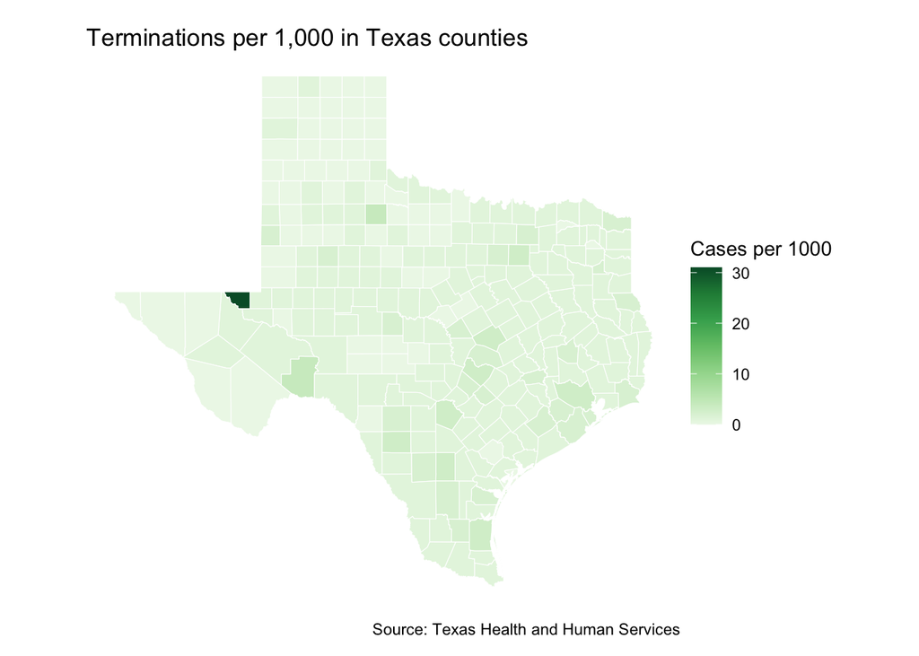

```r
terminations_rates_2020_plot <- terminations_rates_2020 %>%
  ggplot() +
  geom_sf(aes(fill = terminations_per_pop), color = "white", size = .2) +
  theme_void() +
  labs(
    title = "Terminations per 1,000 in Texas counties",
    caption = "Source: Texas Health and Human Services"
  ) +
  scale_fill_distiller(
    palette = "Greens",
    direction = 1,
    name = "Cases per 1000"
  ) +
  theme(plot.margin = unit(c(10,0,10,0), "pt"))

terminations_rates_2020_plot
```

## Export for datawrapper

### Step one

Select only the data we need so we can clean it up and export for datawrapper

```r
datawrapper_rates <-  terminations_rates_2020 %>%
rename(
    county = name
  )  %>%
  mutate(
    county = str_to_title(county)
  ) %>%
  select(
    county,
    geoid,
    terminations_per_pop
  ) %>%
  arrange(county)

datawrapper_rates %>% write_csv("data-processed/datawrapper.csv") # export to csv so we can hackily get rid of geometry in the next step
```

### Step 2

```r
data_wrapper_clean <- read_csv("data-processed/datawrapper.csv") %>%
  select(-geometry) # get rid of geometry
data_wrapper_clean %>% write_clip(allow_non_interactive = T)
```

### Datawrapper chart for story:

Link to datawrapper chart here: [2020 abortion rates](https://datawrapper.dwcdn.net/Hnv4C/1/)

**Question**: what’s going on in Loving, King, and Terrell counties?

**Answer**: Loving has a tiny population (64 people), and in 2020 there were 2 abortions performed there. King, with a population of 265 had 1 abortion, and in Terrell (pop 760), there were 3 abortions in 2020.

**follow-up question**: What were those county’s numbers the other years? Let’s take a look!

```r
county_terminations_2020 %>%
  filter(
    name == "LOVING" | name == "TERRELL" | name == "KING"
  ) %>%
  group_by(name)
```

| geoid | name | variable | total_pop | geometry | year | asian | hispanic | white | black | native_american | other | race_not_stated | total_terminations | under_15_years | x15_to_19_years | x20_to_24_years | x25_to_29_years | x30_to_34_years | x35_to_39_years | x40_years | age_not_stated | terminations_per_pop |
| --- | --- | --- | --- | --- | --- | --- | --- | --- | --- | --- | --- | --- | --- | --- | --- | --- | --- | --- | --- | --- | --- | --- |
| 48269 | KING | P1_001N | 265 |  | 2020 | 0 | 0 | 0 | 1 | 0 | 0 | 0 | 1 | 0 | 0 | 1 | 0 | 0 | 0 | 0 | 0 | 4 |
| 48301 | LOVING | P1_001N | 64 |  | 2020 | 0 | 0 | 2 | 0 | 0 | 0 | 0 | 2 | 0 | 0 | 0 | 1 | 1 | 0 | 0 | 0 | 31 |
| 48443 | TERRELL | P1_001N | 760 |  | 2020 | 0 | 3 | 0 | 0 | 0 | 0 | 0 | 3 | 0 | 1 | 0 | 2 | 0 | 0 | 0 | 0 | 4 |

### Loving and Terrell populations

Let’s look at how these counties rank in terms of size compared to other counties

```r
county_terminations_2020 %>%
  arrange(total_pop)
```

| geoid | name | variable | total_pop | geometry | year | asian | hispanic | white | black | native_american | other | race_not_stated | total_terminations | under_15_years | x15_to_19_years | x20_to_24_years | x25_to_29_years | x30_to_34_years | x35_to_39_years | x40_years | age_not_stated | terminations_per_pop |
| --- | --- | --- | --- | --- | --- | --- | --- | --- | --- | --- | --- | --- | --- | --- | --- | --- | --- | --- | --- | --- | --- | --- |
| 48301 | LOVING | P1_001N | 64 |  | 2020 | 0 | 0 | 2 | 0 | 0 | 0 | 0 | 2 | 0 | 0 | 0 | 1 | 1 | 0 | 0 | 0 | 31 |
| 48269 | KING | P1_001N | 265 |  | 2020 | 0 | 0 | 0 | 1 | 0 | 0 | 0 | 1 | 0 | 0 | 1 | 0 | 0 | 0 | 0 | 0 | 4 |
| 48261 | KENEDY | P1_001N | 350 |  | 2020 | 0 | 1 | 0 | 0 | 0 | 0 | 0 | 1 | 0 | 0 | 0 | 1 | 0 | 0 | 0 | 0 | 3 |
| 48311 | MCMULLEN | P1_001N | 600 |  | 2020 | 0 | 1 | 0 | 1 | 0 | 0 | 0 | 2 | 0 | 0 | 1 | 1 | 0 | 0 | 0 | 0 | 3 |
| 48033 | BORDEN | P1_001N | 631 |  | 2020 | 0 | 0 | 1 | 0 | 0 | 0 | 0 | 1 | 0 | 0 | 1 | 0 | 0 | 0 | 0 | 0 | 2 |
| 48263 | KENT | P1_001N | 753 |  | 2020 | 0 | 0 | 0 | 1 | 0 | 0 | 0 | 1 | 0 | 0 | 0 | 0 | 1 | 0 | 0 | 0 | 1 |
| 48443 | TERRELL | P1_001N | 760 |  | 2020 | 0 | 3 | 0 | 0 | 0 | 0 | 0 | 3 | 0 | 1 | 0 | 2 | 0 | 0 | 0 | 0 | 4 |
| 48393 | ROBERTS | P1_001N | 827 |  | 2020 | 0 | 0 | 0 | 0 | 0 | 0 | 0 | 0 | 0 | 0 | 0 | 0 | 0 | 0 | 0 | 0 | 0 |
| 48345 | MOTLEY | P1_001N | 1063 |  | 2020 | 0 | 0 | 1 | 0 | 0 | 0 | 0 | 1 | 0 | 0 | 1 | 0 | 0 | 0 | 0 | 0 | 1 |
| 48155 | FOARD | P1_001N | 1095 |  | 2020 | 0 | 0 | 0 | 0 | 0 | 0 | 0 | 0 | 0 | 0 | 0 | 0 | 0 | 0 | 0 | 0 | 0 |

[output cut: 244 more lines]

**Takeways:**

Loving’s 2020 rate was definitely a fluke, but Terrell has had relatively high rates of 8 (2017), 5 (2018), and 4 (2020) which is kind of interesting given there isn’t an abortion clinic there. King had a rate of 4 for both 2020 and 2019, but rates of zero for the three years prior.

Interestingly, **all three counties are in the 10 least-populace counties of Texas**: Loving ranking #1 least-populace, King #2 least-populous, and Terrell #7.

## Abortions over time

How have the number of abortions changed over the ten years, if at all? Analyze then copy for datawrapper

```r
terminations_over_time <- all_terminations %>%
  group_by(year) %>%
  summarise(total_terminations = sum(total_terminations)) # get total terminations by year

terminations_over_time %>% write_clip(allow_non_interactive = T) # for datawrapper

terminations_over_time
```

| year | total_terminations |
| --- | --- |
| 2010 | 77592 |
| 2011 | 72470 |
| 2012 | 68298 |
| 2013 | 63849 |
| 2014 | 54902 |
| 2015 | 55287 |
| 2016 | 54507 |
| 2017 | 53843 |
| 2018 | 55596 |
| 2019 | 57929 |

[output cut: 1 more lines]

### Plot terminations over time

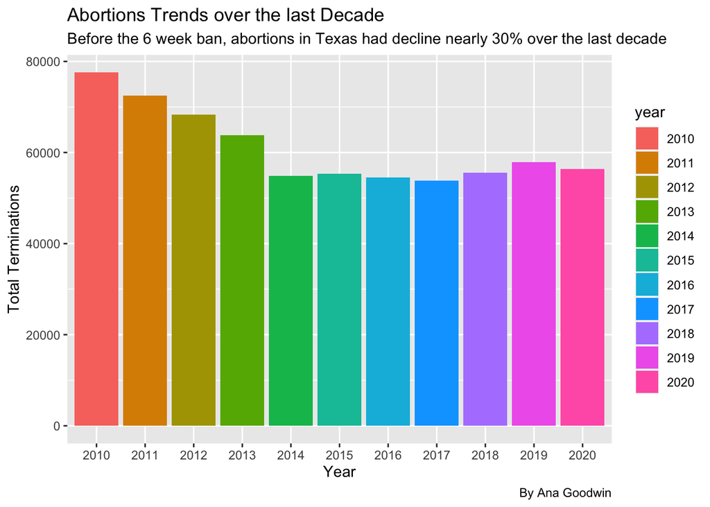

```r
ggplot(terminations_over_time, aes(x = year, y = total_terminations)) + # set x and y axis
  geom_col(aes(fill = year)) + # add columns
  labs(
    title = "Abortions Trends over the last Decade",
    subtitle = "Before the 6 week ban, abortions in Texas had decline nearly 30% over the last decade",
    caption = "By Ana Goodwin",
    x = "Year",
    y = "Total Terminations"
  )
```

## Race and terminations

Analyze the following:

- Were any specific races over-represented in terminations in 2020?
- Have any groups seen major increases or decreases in their numbers the last decade?

```r
terminations_by_race <- all_terminations %>%
  select(
    -(total_terminations:age_not_stated) #get rid of age columns
  ) %>%
  pivot_longer(
    cols = asian:race_not_stated, # select columns to pivot
    names_to = "race", # new column name
    values_to = "terminations"
  ) %>%
  mutate(
    race = recode(
      race,
      "other" = "other/unknown",
      "race_not_stated" = "other/unknown",
      "native_american" = "native american"
    )
  ) %>%
  group_by(year, race) %>% # group by race
  summarise(
    total_terminations = sum(terminations) # add all the termination counts together
  )
terminations_by_race
```

| year | race | total_terminations |
| --- | --- | --- |
| 2010 | asian | 3436 |
| 2010 | black | 19161 |
| 2010 | hispanic | 29801 |
| 2010 | native american | 142 |
| 2010 | other/unknown | 1442 |
| 2010 | white | 23610 |
| 2011 | asian | 3198 |
| 2011 | black | 17916 |
| 2011 | hispanic | 27220 |
| 2011 | native american | 167 |

[output cut: 56 more lines]